# Cluster Analysis Demo

The aim of this analysis is to see whether the clustering results on the developmental trajectories of different brain pacels are consistent through different sites. Since the whole study need to use data collected from different parts of the world. In this analysis, we used the data from HBN.

## Load data and packages

We gonna use the post-ComBat data from the previous combat.ipynb here.

```r
library(dendextend)
```

```r
library(colorspace)
library(ggplot2)
library(dplyr)
hcp_si = read.csv('after_demo.csv', as.is = T)[,-1]
group_data = list()
group_data[[1]] = hcp_si[hcp_si$group == 0,]
group_data[[2]] = hcp_si[hcp_si$group == 1,]
group_data[[3]] = hcp_si[hcp_si$group == 2,]
sites = c('SI', 'RU', 'CBIC')
```

## Define utlity functions

```r
multiplot <- function(..., plotlist=NULL, file, cols=1, layout=NULL) {
  #This fuction is used to plot the subplots in the plotlist,
  #Or you can just feed in indivual subplots.


  library(grid)

  # Make a list from the ... arguments and plotlist
  plots <- c(list(...), plotlist)

  numPlots = length(plots)

  # If layout is NULL, then use 'cols' to determine layout
  if (is.null(layout)) {
    # Make the panel
    # ncol: Number of columns of plots
    # nrow: Number of rows needed, calculated from # of cols
    layout <- matrix(seq(1, cols * ceiling(numPlots/cols)),
                     ncol = cols, nrow = ceiling(numPlots/cols))
  }

  if (numPlots==1) {
    print(plots[[1]])

  } else {
    # Set up the page
    grid.newpage()
    pushViewport(viewport(layout = grid.layout(nrow(layout), ncol(layout))))

    # Make each plot, in the correct location
    for (i in 1:numPlots) {
      # Get the i,j matrix positions of the regions that contain this subplot
      matchidx <- as.data.frame(which(layout == i, arr.ind = TRUE))

      print(plots[[i]], vp = viewport(layout.pos.row = matchidx$row,
                                      layout.pos.col = matchidx$col))
    }
  }
}


find_match = function(matric1, matric2, rown1, rown2){
  #This function is used for finding the match of different clustering results.
  #matric1 : (n_feature, n_prediction) matrix
  #matric2 : (n_feature, n_prediction) matrix
  #Returns :
  #or : array-like
  #The cluster label in matric1 that each cluster in matric2 matched to


  rownames(matric1) = 1:nrow(matric1)
  rownames(matric2) = 1:nrow(matric1)
  cr = as.data.frame(cor(t(matric1), t(matric2),use='complete.obs'))
  cr = cbind(cr, rep(-1, nrow(cr)))
  or = c()
  for(i in 1:nrow(cr)){
    v = cr[i, !colnames(cr) %in% or]
    m = which.max(v)
    m = colnames(v)[m]
    or = c(or,m)
    #  fff = as.data.frame(fff)
  }
  return(or)
}
```

## Fit GAMS for each variable~Age and get the prediction

We fitted GAMs(Generalized Additive Model) to get the developmental trajectry for each feature.

In statistics, a generalized additive model is a generalized linear model in which the linear predictor depends linearly on unknown smooth functions of some predictor variables, and interest focuses on inference about these smooth functions. GAMs were originally developed by Trevor Hastie and Robert Tibshirani to blend properties of generalized linear models with additive models.

$g(E(Y)) = \beta_0 + f_1(x_1)+f_2(x_2)+...$, where $f(x)$ is a smooth function of x. In this analysis, the model is super simple: $E(y) = \beta_0+\beta_1f_1(age)+\beta_2f_2(age)+....$

And here for the demo, I’ll just do it on the volume of parcels.

1. Define new data for prediction

```r
age_vec = seq(5,21,0.1)
new_age = data.frame(age_vec)
colnames(new_age) = 'age'
```

2. Fit model and save predictions

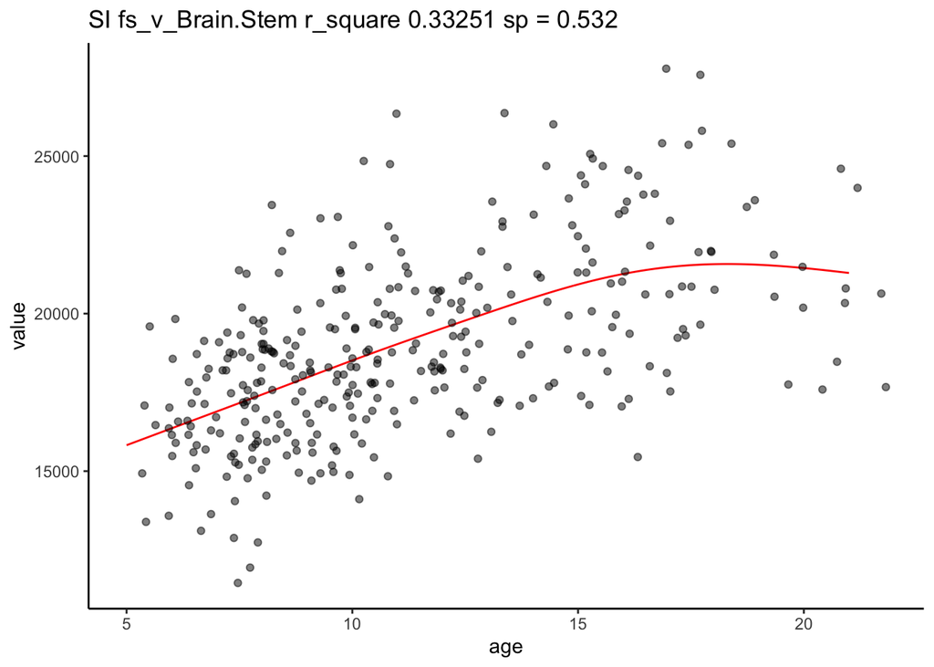

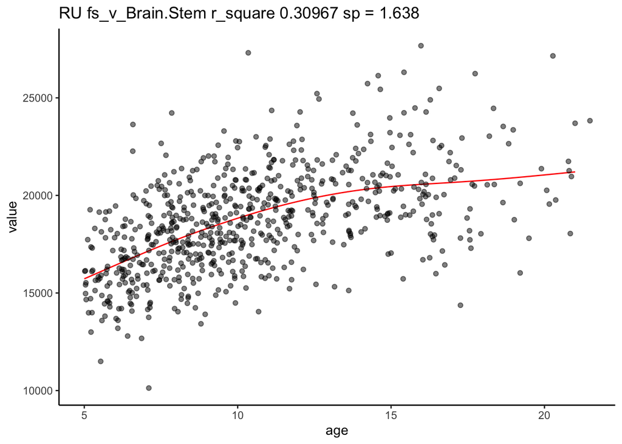

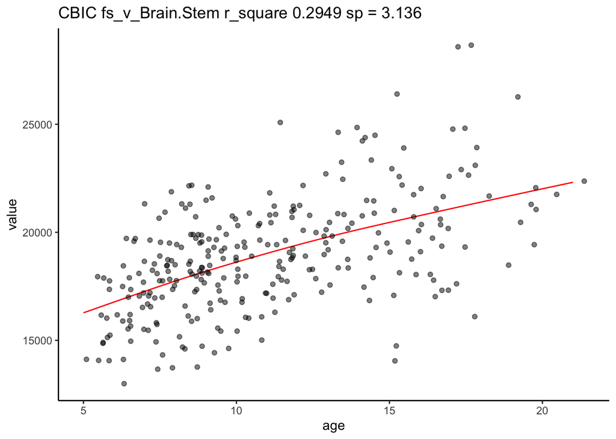

```r
d_l = list()
r_square_l = list()
ssp_l = list()
for (si in c(1:3)){
  d = double()
  r_square = c()
  ssp=c()
  for (i in colnames(group_data[[si]])[1:169]){
    gami = mgcv::gam(group_data[[si]][,i]~s(age,sp=-1), data = group_data[[si]])
    predict = predict(gami, newdata = new_age)
    d = rbind(d,predict)
    r_square = c(r_square, summary(gami)$r.sq)
    ssp = c(ssp,gami['sp'][[1]])
  }
  rownames(d) = colnames(group_data[[si]])[1:169]
  names(r_square) = colnames(group_data[[si]])[1:169]
  names(ssp) = colnames(group_data[[si]])[1:169]
  d_l[[si]] = d
  r_square_l[[si]] = r_square
  ssp_l[[si]] = ssp


  ooo = rownames(d)[order(r_square, decreasing = T)]
  df_pre = data.frame(age = age_vec, value = d[ooo[1],])
  df_data = data.frame(age = group_data[[si]][,'age'], value = group_data[[si]][,ooo[1]])
  p2 = ggplot() +
    geom_line(df_pre, mapping = aes(x=age, y=value), col='Red') +
    #geom_point(df, mapping = aes(x=age, y=v)) +
    geom_point(df_data, mapping = aes(x = age, y =value), alpha = 0.5)+
    ggtitle(paste(sites[si], ' ', ooo[1],' r_square ', round(r_square[ooo[1]],5), ' sp = ', round(ssp[ooo[1]],3),sep=''))+
    theme_bw() +
    theme(panel.border = element_blank(), panel.grid.major = element_blank(), panel.grid.minor = element_blank(), axis.line = element_line(colour = "black"))
  print(p2)
}
```

## Build hierarchical cluster analysis for each site

We build hierarchical clustering model for each site based on the predictions of the GAMs. Using hierarchical clustering is easier for visulization and also we can see how the clustering tree splits.

```r
hclust_c_l = list()
for (i in c(1:3)){
  dist_mat <- cor(t(d_l[[i]]))
  dist_mat = 1 - dist_mat

  dist_c_si = as.dist(dist_mat)

  hclust_c_l[[i]] <- hclust(dist_c_si, method = 'average')
}
```

## Visualize clustering trees

```r
setwd('Cluster_ana/')
dir.create('cluster_ana_v')
setwd('cluster_ana_v')
pdf('cluster_hcp.pdf')
for (c_number in c(2:5)){
  # Cut the template tree
  # Get the mean trajectries for cluster matching

  cut_t_si <- cutree(hclust_c_l[[1]], k=c_number)
  mean_t_si = double()
  for(i in c(1:c_number)){
    if (sum(cut_t_si==i) ==1) {
      after_scale = t(scale(d_l[[1]][cut_t_si==i, ]))
    } else{
      after_scale = t(scale(t(d_l[[1]][cut_t_si==i, ])))
    }
    mean = apply(after_scale, 2, mean, na.rm = T)
    mean_t_si = rbind(mean_t_si, mean)
  }
  clu_t_si = unique(cut_t_si[labels(hclust_c_l[[1]])])

  #Cut tht clustering for different site
  #find the match of each site

  ind_c_l=list()
  clu_c_l=list()
  cut_l = list()
  for (si in c(1:3)) {
    cut_c <- cutree(hclust_c_l[[si]], k=c_number)
    cut_l[[si]] = cut_c
    mean_c = double()
    for(i in c(1:c_number)){
      if (sum(cut_c==i)==1) {
        after_scale = t(scale(d_l[[si]][cut_c==i, ]))
      } else{
        after_scale = t(scale(t(d_l[[si]][cut_c==i, ])))
      }
      mean = apply(after_scale, 2, mean, na.rm = T)
      mean_c = rbind(mean_c, mean)
    }

    clu_c_l[[si]] = unique(cut_c[labels(hclust_c_l[[si]])])
    ind_c_l[[si]] = as.integer(find_match(mean_c, mean_t_si))
  }

  # Get the color map and match them todifferent cluster tree
  # Plot the clustering tree
  col_all = rainbow_hcl(10,c=90)


  par(mfrow=c(3,1))
  for (si in c(1:3)){
    avg_dend_obj <- as.dendrogram(hclust_c_l[[si]])
    col_si = col_all[ind_c_l[[si]]][clu_c_l[[si]]]
    avg_col_dend <- color_branches(avg_dend_obj, k=c_number, col = col_si)
    plot(avg_col_dend, main = paste('Dendrogram for',sites[si]))
  }

  #Create folder to save clustering results
  dir.create(paste(c_number,'_cluster',sep=''))
  dir.create(paste(c_number,'_cluster/',sites[1],sep = ''))
  dir.create(paste(c_number,'_cluster/',sites[2],sep = ''))
  dir.create(paste(c_number,'_cluster/',sites[3],sep = ''))

  # Generate plotlist for mean trajectories
  plot_list=list()
  var_list = list()

  for (si in c(1:3)){
    cut_c_v = rep(0, length(cut_l[[si]]))
    for(i in 1:c_number){
      cut_c_v[cut_l[[si]]==i] = ind_c_l[[si]][i]
    }
    for(i in unique(cut_c_v)){
      dir.create(paste(c_number,'_cluster/',sites[si],'/cluster_',i,sep = ''))
      if (sum(cut_c_v==i)==1) {
        after_scale = t(scale(d_l[[si]][cut_c_v==i, ]))
      } else{
        after_scale = t(scale(t(d_l[[si]][cut_c_v==i, ])))
      }
      mean = apply(after_scale, 2, mean, na.rm = T)
      sd = apply(after_scale, 2, sd, na.rm = T)
      df = data.frame(age = age_vec, mean = mean, sd = sd)
      p = ggplot(df, aes(x=age, y=mean)) +
        geom_line(col=col_all[i]) +
        geom_point(col=col_all[i])+
        geom_errorbar(aes(ymin=mean-sd, ymax=mean+sd), width=0.1,alpha = 0.1, col=col_all[i])+
        ylab('value')+labs(title = paste('cluster',i,'\n N =',  sum(cut_c_v==i)))+
        theme(axis.text=element_text(size=6), axis.title=element_text(size=6))
      plot_list[[3*(i-1)+si]]=p
      var_list[[3*(i-1)+si]]=rownames(d_l[[si]])[cut_c_v==i]

      write(rownames(d_l[[si]])[cut_c_v==i],paste(c_number,'_cluster/',sites[si],'/cluster_',i,'/variable.txt',sep = ''),sep = '\n')
      write(r_square_l[[si]][cut_c_v==i],paste(c_number,'_cluster/',sites[si],'/cluster_',i,'/r_square.txt',sep = ''),sep = '\n')
    }
  }

  for (i in c(1:c_number)){
    over = length(Reduce(intersect, var_list[(i*3-2):(i*3)]))
    perc = round(over/min(sapply(var_list[(i*3-2):(i*3)], length)),2)
    plot_list[[3*i]] = plot_list[[3*i]] + labs(title = paste0('cluster ',i,'\n N =',  sum(cut_c_v==i), '\n Overlap = ',  over, ',', perc*100, '%'))
  }




  multiplot(plotlist = plot_list, cols = c_number)
}

dev.off()
```